# Understanding Alignments

Mark Dunning

10 June 2016

# Outline

- How aligned reads are represented
- Visualising aligned reads in IGV
- Looking at aligned reads in R and Bioconductor

# Understanding file formats for aligned reads

Unlike most of Bioinfomatics, a *single standard* file format has emerged for aligned reads. Moreoever, this file format is consistent regardless of whether you have DNA-seq, RNA-seq, ChIP-seq… data.

## The sam file

- **S**equence **A**lignment/**M**ap (sam) http://samtools.github.io/hts-specs/SAMv1.pdf
- *Header* lines followed by tab-delimited lines
  - Header gives information about the alignment and references sequences used
- Same format regardless of sequencing protocol (i.e. RNA-seq, ChIP-seq, DNA-seq etc)
- May contain un-mapped reads

```
@HD     VN:1.0  SO:coordinate
@SQ     SN:chr1 LN:249250621
@SQ     SN:chr10        LN:135534747
@SQ     SN:chr11        LN:135006516
```

```
HWI-ST1001:137:C12FPACXX:7:1115:14131:66670     0       chr1    12805   1       42M4I5M *
0       0       TTGGATGCCCCTCCACACCCTCTTGATCTTCCCTGTGATGTCACCAATATG
CCCFFFFFHHGHHJJJJJHJJJJJJJJJJJJJJJJIJJJJJJJJJJJJIJJ
AS:i:-28        XN:i:0  XM:i:2  XO:i:1XG:i:4   NM:i:6  MD:Z:2C41C2     YT:Z:UU NH:i:3
CC:Z:chr15      CP:i:102518319  XS:A:+  HI:i:0
```

- http://homer.salk.edu/homer/basicTutorial/samfiles.html
- Large size on disk; ~100s of Gb
  - Can be manipulated with standard unix tools; e.g. *cat*, *head*, *grep*, *more*, *less*

## Sam format - key columns

```
HWI-ST1001:137:C12FPACXX:7:1115:14131:66670     0       chr1    12805   1       42M4I5M *
0       0       TTGGATGCCCCTCCACACCCTCTTGATCTTCCCTGTGATGTCACCAATATG
CCCFFFFFHHGHHJJJJJHJJJJJJJJJJJJJJJJIJJJJJJJJJJJJIJJ
AS:i:-28        XN:i:0  XM:i:2  XO:i:1XG:i:4   NM:i:6  MD:Z:2C41C2     YT:Z:UU NH:i:3
CC:Z:chr15      CP:i:102518319  XS:A:+  HI:i:0
```

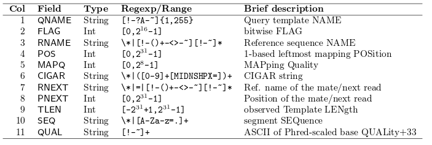

- http://samtools.github.io/hts-specs/SAMv1.pdf
  - Read name
  - Chromosome
  - Position
  - Mapping quality
  - etc…

## Sam file flags

- Represent useful QC information
  - Read is unmapped
  - Read is paired / unpaired
  - Read failed QC
  - Read is a PCR duplicate (see later)

```
system("samtools view paired.bam | grep SRR081708.237649")
```

For instance, a particular read has a flag of 163

```
SRR081708.237649    163 1   10003   6   1S67M   =   10041   105 GACCCTGACCCTAACCCTGACCCTGACCCTAACCCTGACCCTGACCCTAACCCTGACCCTAACCCTAA    S=<====<<>=><?=?=?>==@??;?>@@@=??@@????@??@?>?@@<@>@'@=?=??=<=>?>?=Q    ZA:Z:<&;0;0;;308;68M;68><@;0;0;;27;;>   MD:Z:5A11A5A11A5A11A13  RG:Z:SRR081708  NM:i:6  OQ:Z…
```

## Derivation

|  | ReadHasProperty | Binary | MultiplyBy |
| --- | --- | --- | --- |
| isPaired | TRUE | 1 | 1 |
| isProperPair | TRUE | 1 | 2 |
| isUnmappedQuery | FALSE | 0 | 4 |
| hasUnmappedMate | FALSE | 0 | 8 |
| isMinusStrand | FALSE | 0 | 16 |
| isMateMinusStrand | TRUE | 1 | 32 |
| isFirstMateRead | FALSE | 0 | 64 |
| isSecondMateRead | TRUE | 1 | 128 |
| isSecondaryAlignment | FALSE | 0 | 256 |
| isNotPassingQualityControls | FALSE | 0 | 512 |
| isDuplicate | FALSE | 0 | 1024 |

Value of flag is given by 1x1 + 1x2 + 0x4 + 0x8 + 0x16 + 1x32 + 0x64 + 1x128 + 0x256 + 0x512 + 0x1024 = 163

See also

- https://broadinstitute.github.io/picard/explain-flags.html

## samtools

`samtools` is one of the most-popular ngs-related tools and has a wealth of tools for dealing with files in `.bam` and `.sam` format. If you are going to start processing your own data, the chances are you’ll be using `samtools` a lot. Typing `samtools` in a terminal will give a quick overview of the functions available, and importantly, the version number of the software.

```
samtools
```

More information about a particular command within samtools can be displayed by printing `samtools` followed by the name of the command. For example, the `samtools view` command can convert a `.sam` file into a compressed version called a `.bam` file. This is a very-common step in an NGS workflow.

```
samtools view
```

So a `.bam` file is

- *Exactly* the same information as a sam file
- ..except that it is *binary* version of sam
- compressed around x4
- However, attempting to read with standard unix tools `cat`, `head` etc will print garbage to the screen

When viewing a `.sam` or `.bam`, we can choose to just view the *header* information

```
samtools view -H paired.bam
```

The `samtools view` command needs to be used with a bit of care if not selecting the `-H` option. Unless directed otherwise, `samtools` will print the entire contents of the file to the screen (“the standard output”). We usually “*pipe*” the output to another unix command, such as `head`

```
samtools view paired.bam | head
```

```
samtools view 1:1-100000 random.bam
```

### Other useful samtools commands

```
samtools sort
```

- Sorting
  - The reads in a newly-aligned `.sam` file will probably be sorted according to the order they were generated by the sequencer
  - Reads can be sorted according to genomic position
  - Which allows us to access the file more easily

```
samtools index
```

- Indexing
  - Allow efficient access
  - Producing a file `.bai` in the same directory

```
samtools flagstat
```

- Collates quality control information from the *“flags”*

```
$ samtools flagstat paired.bam
12581680 + 0 in total (QC-passed reads + QC-failed reads)
177715 + 0 duplicates
12581680 + 0 mapped (100.00%:-nan%)
12581680 + 0 paired in sequencing
6291126 + 0 read1
6290554 + 0 read2
12581680 + 0 properly paired (100.00%:-nan%)
12581680 + 0 with itself and mate mapped
0 + 0 singletons (0.00%:-nan%)
0 + 0 with mate mapped to a different chr
0 + 0 with mate mapped to a different chr (mapQ>=5)
```

Typically, you will be dealing with `.bam` files that are

- indexed
- sorted
- have had *PCR duplicates* marked

## About PCR duplicates…

- Marking of PCR duplicates
  - PCR amplification errors can cause some sequences to be over-represented
  - Chances of any two sequences aligning to the same position are *unlikely*
  - Caveat: obviously this depends on amount of the genome you are capturing

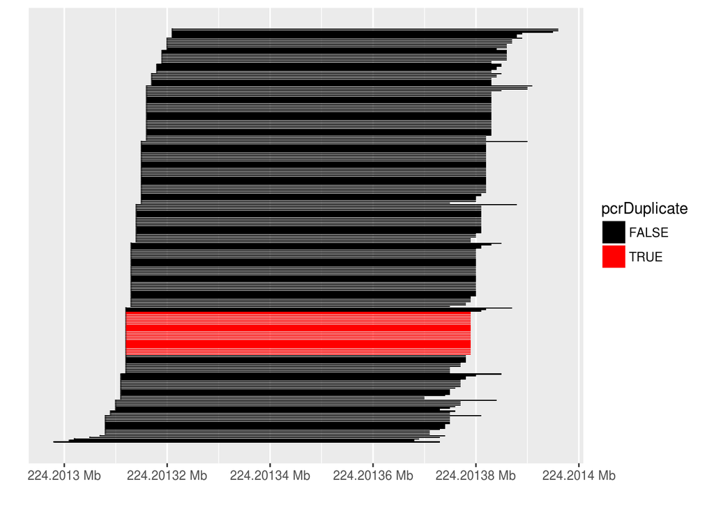

- Such reads are *marked* but not usually removed from the data
- Most downstream methods will ignore such reads
- Typically, [*picard*](http://broadinstitute.github.io/picard/) is used

Picard is another very-common tool in NGS analysis with lots of conversion, manipulation tools. If you are seriously considering getting into NGS analysis, it is worth getting to know.

```
java -jar $PICARD -h
```

# Viewing aligned reads in IGV

- Once our bam files have been *indexed* we can view them in IGV
- This is **highly recommended**
- Check-out [our colleagues’ course](http://mrccsc.github.io/IGV_course/) for more details

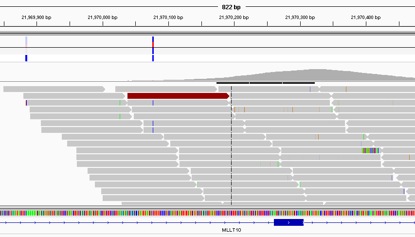

igv

# Processing with R and Bioconductor

To understand how to process aligned reads with Bioconductor, we need to introduce a key data-type.

## Core data-type 1: Genome Intervals

- A Genome is typically represented as linear sequence
- Ranges are an ordered set of consecutive integers defined by a start and end position
  - start $\le$ end
- Ranges are a common scaffold for many genomic analyses
- Ranges can be associated with genomic information (e.g. gene name) or data derived from analysis (e.g. counts)
- The `IRanges` package in Bioconductor allows us to work with intervals
  - one of the aims of Bioconductor is to encourage core object-types and functions
  - `IRanges` is an example of this

`IRanges` is crucial for many packages. The [landing page](http://bioconductor.org/packages/release/bioc/html/IRanges.html) for the package lists just how many packages depend on it. If you want to find-out more, or look at the technical details, check out the [PLoS Computational Biology paper](http://journals.plos.org/ploscompbiol/article?id=10.1371/journal.pcbi.1003118).

## Example

Suppose we want to capture information on the following intervals

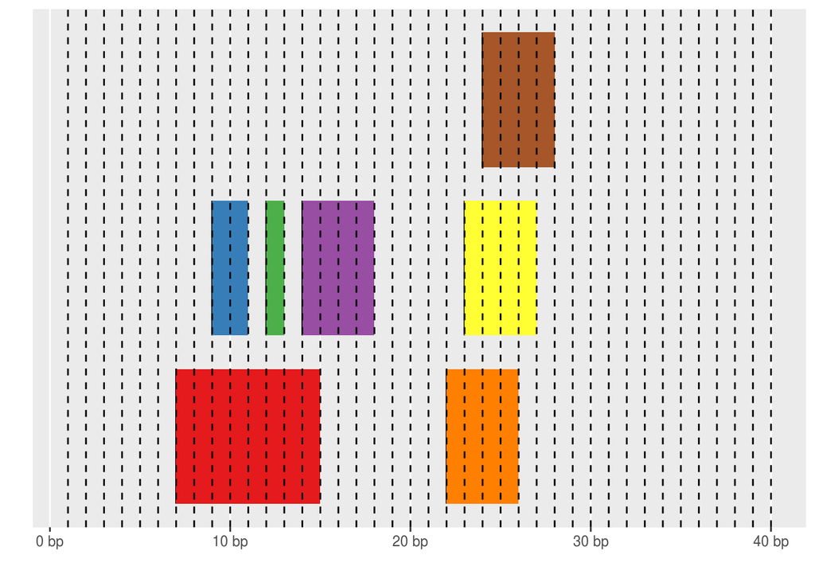

- The `IRanges` function from the `IRanges` package is used to *construct* a new object
  - think `data.frame`, `vector` or `matrix`
  - it’s structure is quite unlike anything we’ve seen so far

```r
library(IRanges)
ir <- IRanges(
start = c(7,9,12,14,22:24),
end=c(15,11,13,18,26,27,28))
str(ir)
```

```
## Formal class 'IRanges' [package "IRanges"] with 6 slots
##   ..@ start          : int [1:7] 7 9 12 14 22 23 24
##   ..@ width          : int [1:7] 9 3 2 5 5 5 5
##   ..@ NAMES          : NULL
##   ..@ elementType    : chr "integer"
##   ..@ elementMetadata: NULL
##   ..@ metadata       : list()
```

- Typing the name of the object will print a summary of the object to the screen
  - useful compared to display methods for data frames, which print the whole object
- the square brackets `[]` should give a hint about how to access the data…

```r
ir
```

```
## IRanges object with 7 ranges and 0 metadata columns:
##           start       end     width
##       <integer> <integer> <integer>
##   [1]         7        15         9
##   [2]         9        11         3
##   [3]        12        13         2
##   [4]        14        18         5
##   [5]        22        26         5
##   [6]        23        27         5
##   [7]        24        28         5
```

Additionally, we can give our ranges names

```r
ir <- IRanges(
start = c(7,9,12,14,22:24),
end=c(15,11,13,18,26,27,28),names=LETTERS[1:7])
ir
```

```
## IRanges object with 7 ranges and 0 metadata columns:
##         start       end     width
##     <integer> <integer> <integer>
##   A         7        15         9
##   B         9        11         3
##   C        12        13         2
##   D        14        18         5
##   E        22        26         5
##   F        23        27         5
##   G        24        28         5
```

- So `IRanges` can be treated as if they were *vectors*
  - no new rules to learn
    - if we can subset vectors, we can subset ranges
  - vector operations are efficient
  - Remember, square brackets `[` to subset
  - Inside the brackets, put a numeric vector to specify the `indices` that you want values for
    - e.g. get the first two intervals in the object using the `:` shortcut

```r
ir[1:2]
```

```
## IRanges object with 2 ranges and 0 metadata columns:
##         start       end     width
##     <integer> <integer> <integer>
##   A         7        15         9
##   B         9        11         3
```

```r
ir[c(2,4,6)]
```

```
## IRanges object with 3 ranges and 0 metadata columns:
##         start       end     width
##     <integer> <integer> <integer>
##   B         9        11         3
##   D        14        18         5
##   F        23        27         5
```

- If we want to extract the properties of the object, the package authors have provided some useful functions
  - we call these *accessor* functions
  - We don’t need to know the details of how the objects and implemented to access the data
  - the authors are free to change the implementation at any time
    - we shouldn’t notice the difference
  - the result is a vector with the same length as the number of intervals

```r
start(ir)
```

```
## [1]  7  9 12 14 22 23 24
```

```r
end(ir)
```

```
## [1] 15 11 13 18 26 27 28
```

```r
width(ir)
```

```
## [1] 9 3 2 5 5 5 5
```

## More-complex subsetting

- Recall that ‘*logical*’ vectors can be used in subsetting
  - i.e. `TRUE` or `FALSE`
- Such a vector can be derived using a comparison operator
  - `<`, `>`, `==`

### Exercise

From the object we have just created:-

- What ranges have a width of 5?
- What ranges have a start position greater than 10
- What ranges have a start position greater than 10, and an end position less than 27?

## Manipulating Ranges

When it comes to manipulating intervals, lots of common use-cases are implemented

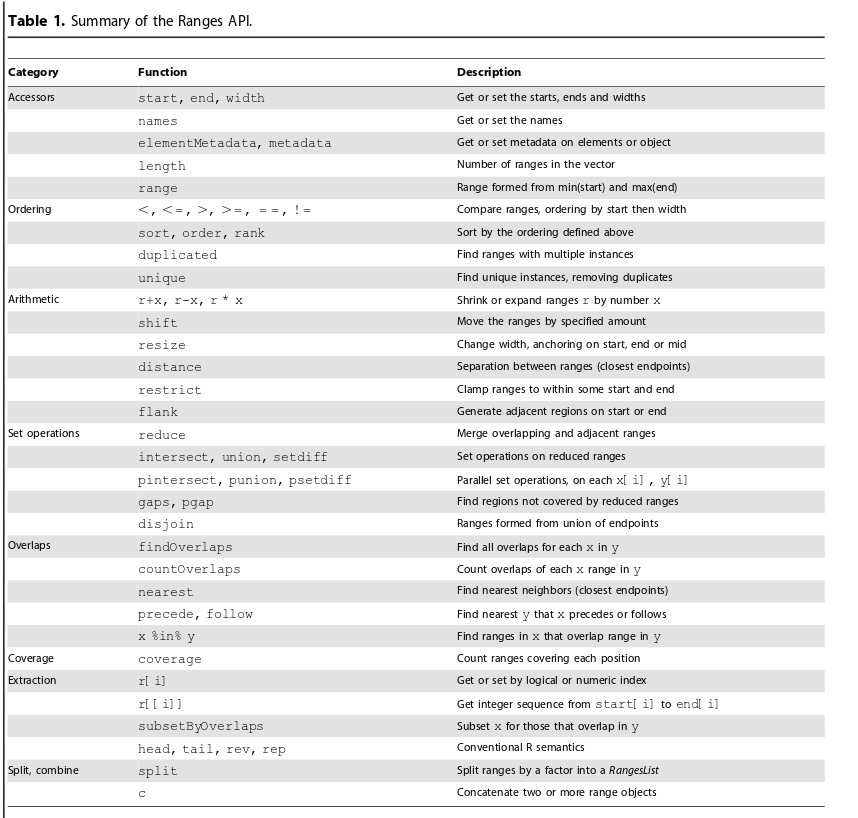

### Shifting

e.g. sliding windows

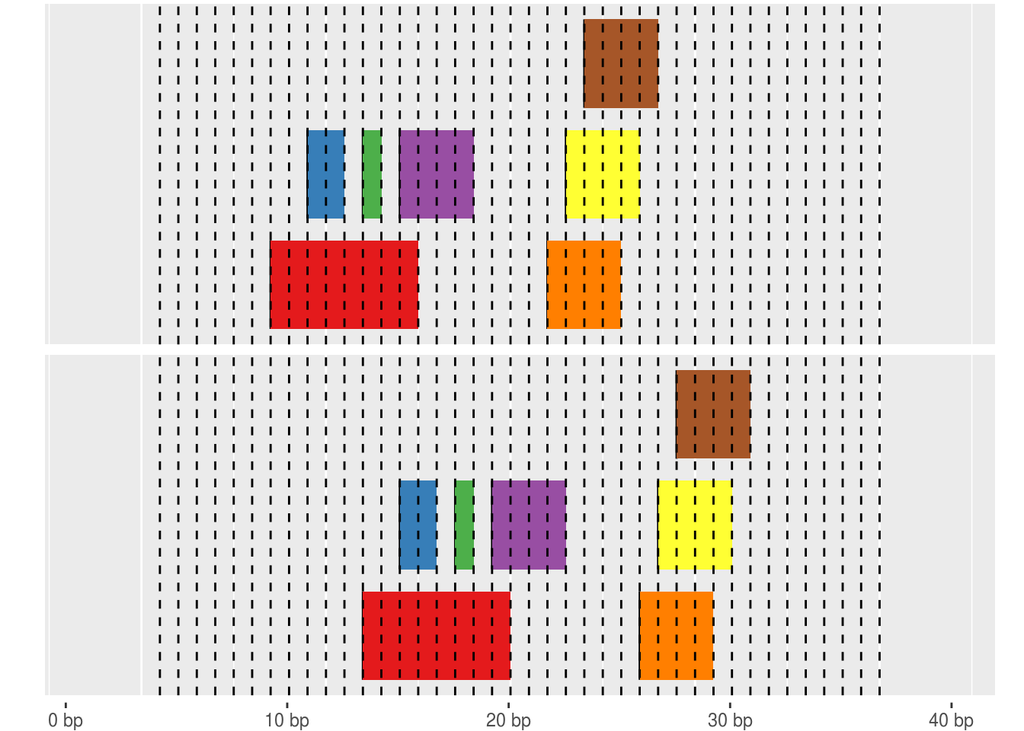

```r
ir
```

```
## IRanges object with 7 ranges and 0 metadata columns:
##         start       end     width
##     <integer> <integer> <integer>
##   A         7        15         9
##   B         9        11         3
##   C        12        13         2
##   D        14        18         5
##   E        22        26         5
##   F        23        27         5
##   G        24        28         5
```

```r
shift(ir, 5)
```

```
## IRanges object with 7 ranges and 0 metadata columns:
##         start       end     width
##     <integer> <integer> <integer>
##   A        12        20         9
##   B        14        16         3
##   C        17        18         2
##   D        19        23         5
##   E        27        31         5
##   F        28        32         5
##   G        29        33         5
```

The Size of shift doesn’t need to be constant

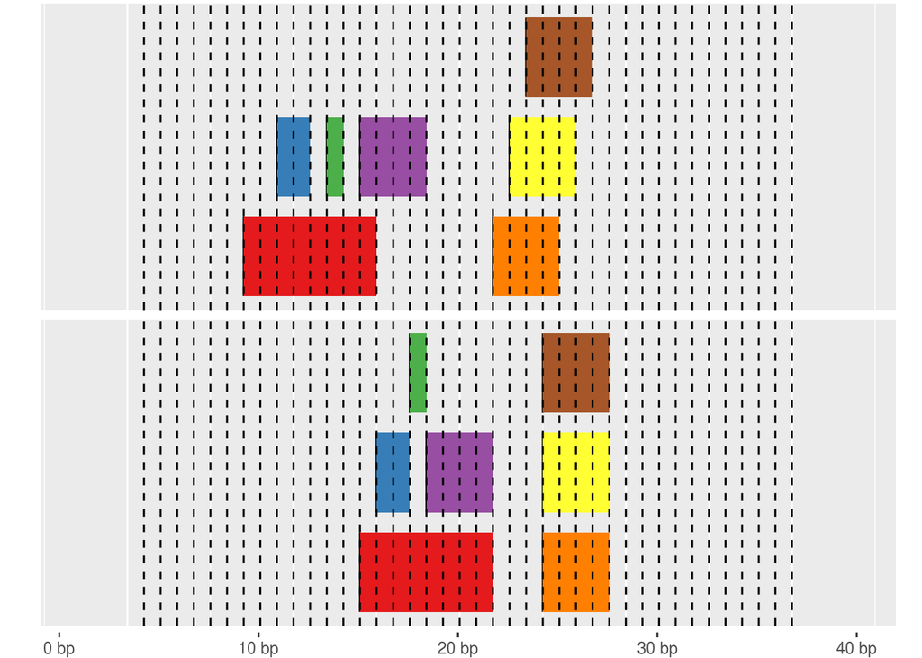

```r
shift(ir, 7:1)
```

```
## IRanges object with 7 ranges and 0 metadata columns:
##         start       end     width
##     <integer> <integer> <integer>
##   A        14        22         9
##   B        15        17         3
##   C        17        18         2
##   D        18        22         5
##   E        25        29         5
##   F        25        29         5
##   G        25        29         5
```

### Resize

e.g. trimming reads

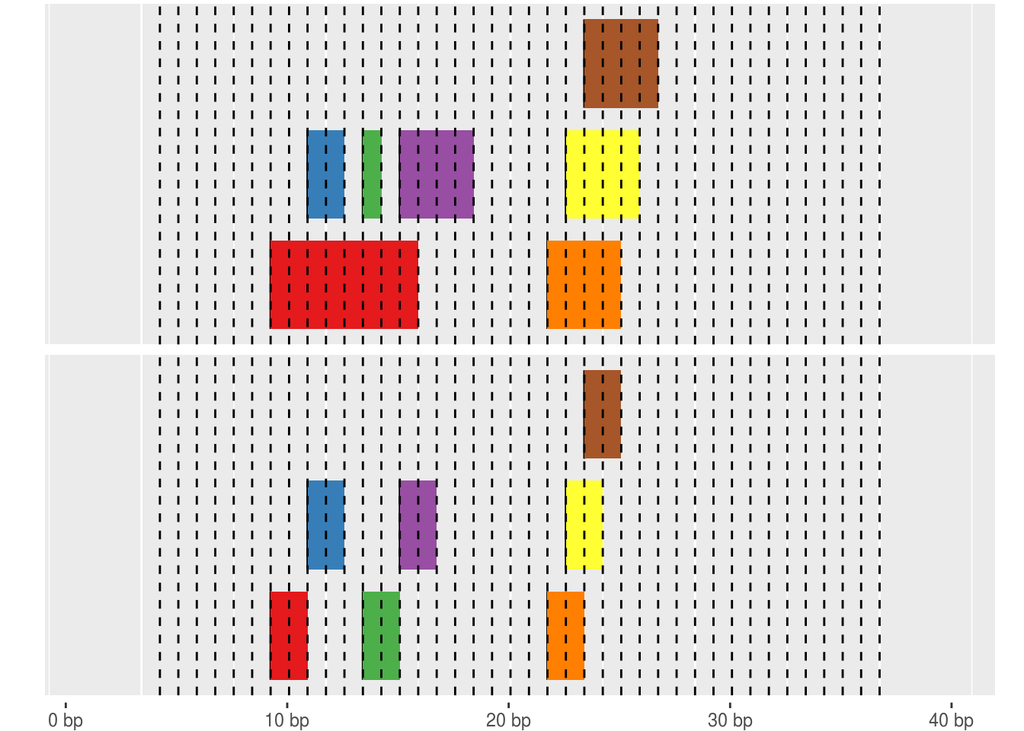

```r
resize(ir,3)
```

```
## IRanges object with 7 ranges and 0 metadata columns:
##         start       end     width
##     <integer> <integer> <integer>
##   A         7         9         3
##   B         9        11         3
##   C        12        14         3
##   D        14        16         3
##   E        22        24         3
##   F        23        25         3
##   G        24        26         3
```

### Exercise

Explain the behaviour of the following:-

```r
resize(ir,3)
```

```
## IRanges object with 7 ranges and 0 metadata columns:
##         start       end     width
##     <integer> <integer> <integer>
##   A         7         9         3
##   B         9        11         3
##   C        12        14         3
##   D        14        16         3
##   E        22        24         3
##   F        23        25         3
##   G        24        26         3
```

```r
resize(ir,3,fix = "start")
```

```
## IRanges object with 7 ranges and 0 metadata columns:
##         start       end     width
##     <integer> <integer> <integer>
##   A         7         9         3
##   B         9        11         3
##   C        12        14         3
##   D        14        16         3
##   E        22        24         3
##   F        23        25         3
##   G        24        26         3
```

```r
resize(ir,3,fix = "end")
```

```
## IRanges object with 7 ranges and 0 metadata columns:
##         start       end     width
##     <integer> <integer> <integer>
##   A        13        15         3
##   B         9        11         3
##   C        11        13         3
##   D        16        18         3
##   E        24        26         3
##   F        25        27         3
##   G        26        28         3
```

```r
resize(ir,3,fix = "center")
```

```
## IRanges object with 7 ranges and 0 metadata columns:
##         start       end     width
##     <integer> <integer> <integer>
##   A        10        12         3
##   B         9        11         3
##   C        11        13         3
##   D        15        17         3
##   E        23        25         3
##   F        24        26         3
##   G        25        27         3
```

### Coverage

- Often we want to know how much sequencing we have at particular positions
  - i.e. depth of coverage

`coverage` returns a *Run Length Encoding* - an efficient representation of repeated values. At a whole-chromosome level, we have a large stretch of positions with the same coverage level. It would be rather inefficient to store the data in a vector. Although we can convert between `Rle`objects and vectors.

```r
cvg <- coverage(ir)
cvg
```

```
## integer-Rle of length 28 with 10 runs
##   Lengths: 6 2 7 3 3 1 1 3 1 1
##   Values : 0 1 2 1 0 1 2 3 2 1
```

```r
as.vector(cvg)
```

```
##  [1] 0 0 0 0 0 0 1 1 2 2 2 2 2 2 2 1 1 1 0 0 0 1 2 3 3 3 2 1
```

Often we might want to know what positions exceed a certain coverage level. This we can do using the `slice` function.

```r
slice(cvg,2)
```

```
## Views on a 28-length Rle subject
##
## views:
##     start end width
## [1]     9  15     7 [2 2 2 2 2 2 2]
## [2]    23  27     5 [2 3 3 3 2]
```

## Overlapping

A large set of `IRanges` functionality is designed to deal with overlapping queries. Such operations are common in NGS analysis so we need to have an efficient way of performing them. You will probably come across such operations without even realising it.

- What reads overlap with a particular genomic region?
- What genes are affected by this particular copy-number loss / gain?
- How many variants are in exonic regions?
- For a given set of variants, what genes do they overlap with?
- How many variants does my gene of interest have?

The terminology of overlapping defines a *query* and a *subject*

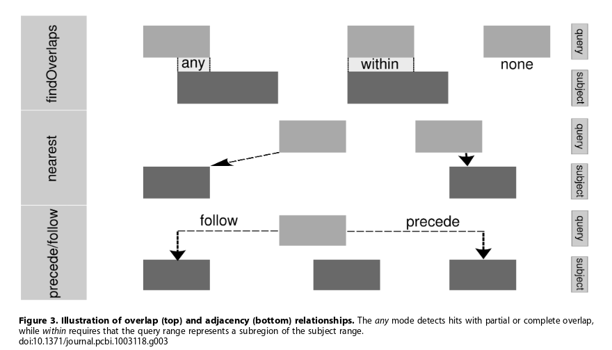

- To illustrate lets start be defining a new set of ranges

```r
ir2 <- IRanges(start = c(1, 14, 27), end = c(13,
    18, 30),names=c("X","Y","Z"))
ir2
```

```
## IRanges object with 3 ranges and 0 metadata columns:
##         start       end     width
##     <integer> <integer> <integer>
##   X         1        13        13
##   Y        14        18         5
##   Z        27        30         4
```

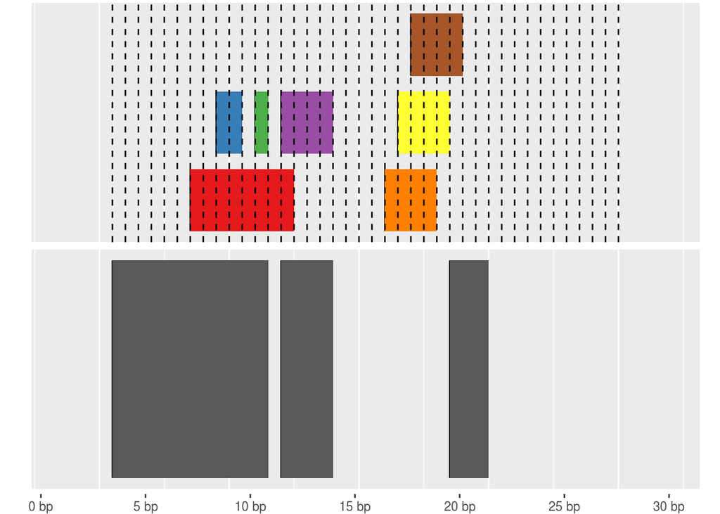

- The `findOverlaps` function can be used for overlap
  - the output isn’t immediately obvious
  - length of output is the number of *hits*
    - each hit is defined by a subject and query index
  - require accessor functions to get the data; `queryHits` and `subjectHits`

```r
query <- ir
subject <- ir2
ov <- findOverlaps(query, subject)
ov
```

```
## Hits object with 7 hits and 0 metadata columns:
##       queryHits subjectHits
##       <integer>   <integer>
##   [1]         1           1
##   [2]         1           2
##   [3]         2           1
##   [4]         3           1
##   [5]         4           2
##   [6]         6           3
##   [7]         7           3
##   -------
##   queryLength: 7 / subjectLength: 3
```

## queryHits and subjectHits

- `queryHits` returns *indices* from the *query*
  - each query may overlap with many in the subject

```r
queryHits(ov)
```

```
## [1] 1 1 2 3 4 6 7
```

- `subjectHits` returns *indices* from the *subject*
  - each subject range may overlap with many in the query

```r
subjectHits(ov)
```

```
## [1] 1 2 1 1 2 3 3
```

- e.g. 1 from the query overlaps with 1 from the subject

## Overlap example - First hit

```r
query[queryHits(ov)[1]]
```

```
## IRanges object with 1 range and 0 metadata columns:
##         start       end     width
##     <integer> <integer> <integer>
##   A         7        15         9
```

```r
subject[subjectHits(ov)[1]]
```

```
## IRanges object with 1 range and 0 metadata columns:
##         start       end     width
##     <integer> <integer> <integer>
##   X         1        13        13
```

It is more common to use the `%over%` shortcut , which tells us (via a `TRUE` or `FALSE`) if every range in the query overlaps with the subject or not. The result can then be used for subset operations.

```r
ir %over% ir2
```

```
## [1]  TRUE  TRUE  TRUE  TRUE FALSE  TRUE  TRUE
```

```r
ir[ir %over% ir2]
```

```
## IRanges object with 6 ranges and 0 metadata columns:
##         start       end     width
##     <integer> <integer> <integer>
##   A         7        15         9
##   B         9        11         3
##   C        12        13         2
##   D        14        18         5
##   F        23        27         5
##   G        24        28         5
```

- If we just wanted to count the number of overlaps for each range, we can use `countOverlaps`
  - result is a vector with length the number of intervals in query
  - e.g. interval 1 in the query overlaps with 2 intervals in the subject

```r
countOverlaps(query,subject)
```

```
## A B C D E F G
## 2 1 1 1 0 1 1
```

- The order of arguments is important

```r
countOverlaps(subject,query)
```

```
## X Y Z
## 3 2 2
```

- Rather than counting, we might want to know which positions are in common

```r
intersect(ir,ir2)
```

```
## IRanges object with 2 ranges and 0 metadata columns:
##           start       end     width
##       <integer> <integer> <integer>
##   [1]         7        18        12
##   [2]        27        28         2
```

- Or which positions are missing

```r
setdiff(ir,ir2)
```

```
## IRanges object with 1 range and 0 metadata columns:
##           start       end     width
##       <integer> <integer> <integer>
##   [1]        22        26         5
```

So far the objects we have been dealing with have been located on the same arbitrary linear scale. When dealing with genomic data, we’ll want to deal with intervals that are located on different chromosomes. The next object-type gives us a way of handling this.

## Introducing GRanges

- `GRanges` are a special kind of `IRanges` object used to manipulate genomic intervals in an efficient manner
- We can define a ‘chromosome’ for each range
  - referred to as seqnames
- we have the option to define a strand
- need to supply a ranges object, as we saw before
- operations on ranges respect the chromosome labels

```r
library(GenomicRanges)
gr <- GRanges(c("A","A","A","B","B","B","B"), ranges=ir)
gr
```

```
## GRanges object with 7 ranges and 0 metadata columns:
##     seqnames    ranges strand
##        <Rle> <IRanges>  <Rle>
##   A        A  [ 7, 15]      *
##   B        A  [ 9, 11]      *
##   C        A  [12, 13]      *
##   D        B  [14, 18]      *
##   E        B  [22, 26]      *
##   F        B  [23, 27]      *
##   G        B  [24, 28]      *
##   -------
##   seqinfo: 2 sequences from an unspecified genome; no seqlengths
```

The object has gained a new variable `seqnames` which can be queried using the function `seqnames`.

```r
seqnames(gr)
```

```
## factor-Rle of length 7 with 2 runs
##   Lengths: 3 4
##   Values : A B
## Levels(2): A B
```

```r
table(seqnames(gr))
```

```
##
## A B
## 3 4
```

The operations we just described can also be applied to `GRanges` objects and it will respect the chromosome information

```r
resize(gr,4)
```

```
## GRanges object with 7 ranges and 0 metadata columns:
##     seqnames    ranges strand
##        <Rle> <IRanges>  <Rle>
##   A        A  [ 7, 10]      *
##   B        A  [ 9, 12]      *
##   C        A  [12, 15]      *
##   D        B  [14, 17]      *
##   E        B  [22, 25]      *
##   F        B  [23, 26]      *
##   G        B  [24, 27]      *
##   -------
##   seqinfo: 2 sequences from an unspecified genome; no seqlengths
```

```r
coverage(gr)
```

```
## RleList of length 2
## $A
## integer-Rle of length 15 with 4 runs
##   Lengths: 6 2 5 2
##   Values : 0 1 2 1
##
## $B
## integer-Rle of length 28 with 8 runs
##   Lengths: 13  5  3  1  1  3  1  1
##   Values :  0  1  0  1  2  3  2  1
```

```r
gr2 <- GRanges("A", ir2)
gr2
```

```
## GRanges object with 3 ranges and 0 metadata columns:
##     seqnames    ranges strand
##        <Rle> <IRanges>  <Rle>
##   X        A  [ 1, 13]      *
##   Y        A  [14, 18]      *
##   Z        A  [27, 30]      *
##   -------
##   seqinfo: 1 sequence from an unspecified genome; no seqlengths
```

```r
gr[gr %over% gr2]
```

```
## GRanges object with 3 ranges and 0 metadata columns:
##     seqnames    ranges strand
##        <Rle> <IRanges>  <Rle>
##   A        A  [ 7, 15]      *
##   B        A  [ 9, 11]      *
##   C        A  [12, 13]      *
##   -------
##   seqinfo: 2 sequences from an unspecified genome; no seqlengths
```

The objects can be really powerful when we can add extra metadata

- `mcols` can be set to be a data frame with one row for each range
- Counts, gene names
  - anything you like!

```r
mcols(gr) <- data.frame(Count = runif(length(gr)), Gene =sample(LETTERS,length(gr)))
gr
```

```
## GRanges object with 7 ranges and 2 metadata columns:
##     seqnames    ranges strand |      Count     Gene
##        <Rle> <IRanges>  <Rle> |  <numeric> <factor>
##   A        A  [ 7, 15]      * | 0.96220613        K
##   B        A  [ 9, 11]      * | 0.04392985        J
##   C        A  [12, 13]      * | 0.70461920        U
##   D        B  [14, 18]      * | 0.26768583        L
##   E        B  [22, 26]      * | 0.49746358        Y
##   F        B  [23, 27]      * | 0.74295148        A
##   G        B  [24, 28]      * | 0.12789588        Z
##   -------
##   seqinfo: 2 sequences from an unspecified genome; no seqlengths
```

The “counts” we have created here can be used in the subset operation

```r
gr[mcols(gr)$Count > 0.5]
```

```
## GRanges object with 3 ranges and 2 metadata columns:
##     seqnames    ranges strand |     Count     Gene
##        <Rle> <IRanges>  <Rle> | <numeric> <factor>
##   A        A  [ 7, 15]      * | 0.9622061        K
##   C        A  [12, 13]      * | 0.7046192        U
##   F        B  [23, 27]      * | 0.7429515        A
##   -------
##   seqinfo: 2 sequences from an unspecified genome; no seqlengths
```

## Representing a gene

- Creating an object to represent a particular gene is easy if we know its coordinates
  - we will look at representing the full gene structure later
    - e.g. exons, introns etc

```r
mygene <- GRanges("chr17", ranges=IRanges(7577851, 7598063))
mygene
```

```
## GRanges object with 1 range and 0 metadata columns:
##       seqnames             ranges strand
##          <Rle>          <IRanges>  <Rle>
##   [1]    chr17 [7577851, 7598063]      *
##   -------
##   seqinfo: 1 sequence from an unspecified genome; no seqlengths
```

At this point `IRanges` and `GRanges` are probably still a bit abstract, so we will demonstrate their utility by looking at a few examples.

## Representing aligned data

We can import reads from a `.bam` file into Bioconductor. However, to set expectations, we should probably say we are not going to be processing the reads from a whole-genome sequencing run in this manner.

A package that can be used to parse a bam file is `GenomicAlignments`

```r
library(GenomicAlignments)
mybam <- readGAlignments("paired.bam")
mybam
```

```
## GAlignments object with 12581680 alignments and 0 metadata columns:
##              seqnames strand       cigar    qwidth     start       end
##                 <Rle>  <Rle> <character> <integer> <integer> <integer>
##          [1]        1      +       1S67M        68     10003     10069
##          [2]        1      +         68M        68     10036     10103
##          [3]        1      +         68M        68     10036     10103
##          [4]        1      +         68M        68     10041     10108
##          [5]        1      -         68M        68     10041     10108
##          ...      ...    ...         ...       ...       ...       ...
##   [12581676]   hs37d5      -         68M        68  35465836  35465903
##   [12581677]   hs37d5      +         68M        68  35466096  35466163
##   [12581678]   hs37d5      -    47M1D21M        68  35466133  35466201
##   [12581679]   hs37d5      +         68M        68  35466270  35466337
##   [12581680]   hs37d5      -         68M        68  35466357  35466424
##                  width     njunc
##              <integer> <integer>
##          [1]        67         0
##          [2]        68         0
##          [3]        68         0
##          [4]        68         0
##          [5]        68         0
##          ...       ...       ...
##   [12581676]        68         0
##   [12581677]        68         0
##   [12581678]        69         0
##   [12581679]        68         0
##   [12581680]        68         0
##   -------
##   seqinfo: 86 sequences from an unspecified genome
```

You should see that the object created, `mybam` is displayed in a similar style to the `IRanges` and `GRanges` we have just been dealing with.

### Exercise

- How many reads are in this bam file?
- How many reads have aligned to each chromosome?

Once we have our reads in this form, we can start to play with some of the functions that we just learnt about. For example, a coverage vector is quite straightforward to obtain:-

```r
bamcov <- coverage(mybam)
bamcov
```

```
## RleList of length 86
## $`1`
## integer-Rle of length 249250621 with 2205292 runs
##   Lengths: 10002    33     5     5    24 ...    30    68    22    67 10080
##   Values :     0     1     3     6     7 ...     0     1     0     1     0
##
## $`2`
## integer-Rle of length 243199373 with 1823103 runs
##   Lengths: 10505    76     2    76  1354 ...   451    68     1    68 10290
##   Values :     0     1     0     1     0 ...     0     1     0     1     0
##
## $`3`
## integer-Rle of length 198022430 with 1437282 runs
##   Lengths: 60087    68    23    68    17 ...    25    24    14    30 66062
##   Values :     0     1     0     1     0 ...     2     3     2     1     0
##
## $`4`
## integer-Rle of length 191154276 with 1196801 runs
##   Lengths:  10046     19     48     21 ...      3      1      1 110045
##   Values :      0      1      2      1 ...      4      3      1      0
##
## $`5`
## integer-Rle of length 180915260 with 1240960 runs
##   Lengths: 10345     1     6     6     1 ...  1774    33    43    33 10055
##   Values :     0     1     2     3     6 ...     0     1     2     1     0
##
## ...
## <81 more elements>
```

As we saw before, the coverage is calculated on each chromosome separately. To access the coverage for a particular chromosome we use the `$` operator.

```r
bamcov$"20"
```

```
## integer-Rle of length 63025520 with 502044 runs
##   Lengths: 60056    68   196     8    60 ...     2    14    49     5 60079
##   Values :     0     1     0     1     2 ...     2     3     2     1     0
```

### Exercise

- What is the mean coverage on chromosome 20?
- What is the maximum?
- How much of the chromosome has zero coverage?
- What regions are covered by more than 50 reads

## Overlapping genes with reads

Rather than looking at reads across the genome, we might be itching to look at that favourite gene of ours.

```r
mygene <- GRanges("chr17", ranges=IRanges(7577851, 7598063))
mygene
```

```
## GRanges object with 1 range and 0 metadata columns:
##       seqnames             ranges strand
##          <Rle>          <IRanges>  <Rle>
##   [1]    chr17 [7577851, 7598063]      *
##   -------
##   seqinfo: 1 sequence from an unspecified genome; no seqlengths
```

The `countOverlaps` function introduced earlier might be an ideal candidate for this kind of investigation.

```r
countOverlaps(mygene, mybam)
```

```
## Warning in .Seqinfo.mergexy(x, y): The 2 combined objects have no sequence levels in common. (Use
##   suppressWarnings() to suppress this warning.)
```

```
## [1] 0
```

What is this this warning message telling us? It’s basically saying that the sequence names are not compatible

```r
table(seqnames(mybam))
```

```
##
##          1          2          3          4          5          6
##    1222361     974687     760716     634872     656322     665565
##          7          8          9         10         11         12
##     621993     515407     500207     538097     605012     580508
##         13         14         15         16         17         18
##     305082     432772     400797     433895     501464     235618
##         19         20         21         22          X          Y
##     422294     267243     139654     201444     314641      63743
##         MT GL000207.1 GL000226.1 GL000229.1 GL000231.1 GL000210.1
##      22951         14       8508        208        186         76
## GL000239.1 GL000235.1 GL000201.1 GL000247.1 GL000245.1 GL000197.1
##        192        146        200        182         82        144
## GL000203.1 GL000246.1 GL000249.1 GL000196.1 GL000248.1 GL000244.1
##         76        130        174        154        100        448
## GL000238.1 GL000202.1 GL000234.1 GL000232.1 GL000206.1 GL000240.1
##        300        120        218        184        150        156
## GL000236.1 GL000241.1 GL000243.1 GL000242.1 GL000230.1 GL000237.1
##        222        378        300         98         84        804
## GL000233.1 GL000204.1 GL000198.1 GL000208.1 GL000191.1 GL000227.1
##        130        226        312       1032        546       1994
## GL000228.1 GL000214.1 GL000221.1 GL000209.1 GL000218.1 GL000220.1
##       1988       2344       2215       3734       1148      27398
## GL000213.1 GL000211.1 GL000199.1 GL000217.1 GL000216.1 GL000215.1
##        860       1514       2000        666        974        622
## GL000205.1 GL000219.1 GL000224.1 GL000223.1 GL000195.1 GL000212.1
##       1628       1066       3120       1140       2108       2030
## GL000222.1 GL000200.1 GL000193.1 GL000194.1 GL000225.1 GL000192.1
##        956        898       1162       1756       2133       4022
##  NC_007605     hs37d5
##      92718     385861
```

```r
table(seqnames(mygene))
```

```
##
## chr17
##     1
```

Before attempting an overlap between two different set of ranges, we need to make sure that there sequences names are compatible. One solution is to be more careful when creating our ranges.

```r
mygene <- GRanges("17", ranges=IRanges(7577851, 7598063))
countOverlaps(mygene, mybam)
```

```
## [1] 225
```

The convenience function `seqlevelsStyle` has been written to help us understand what covention has been used to name the chromosomes

```r
mygene <- GRanges("chr17", ranges=IRanges(7577851, 7598063))
seqlevelsStyle(mygene)
```

```
## [1] "UCSC"
```

```r
seqlevelsStyle(mybam)
```

```
## [1] "NCBI"    "Ensembl"
```

```r
seqlevelsStyle(mygene) <- "NCBI"
countOverlaps(mygene, mybam)
```

```
## [1] 225
```

If we want the actual reads themselves, we can use the `%over%` shortcut from earlier:-

```r
mybam[mybam %over% mygene]
```

```
## GAlignments object with 225 alignments and 0 metadata columns:
##         seqnames strand       cigar    qwidth     start       end
##            <Rle>  <Rle> <character> <integer> <integer> <integer>
##     [1]       17      +         76M        76   7577918   7577993
##     [2]       17      -         76M        76   7577930   7578005
##     [3]       17      +         76M        76   7578191   7578266
##     [4]       17      +         68M        68   7578195   7578262
##     [5]       17      +         68M        68   7578203   7578270
##     ...      ...    ...         ...       ...       ...       ...
##   [221]       17      +         68M        68   7596523   7596590
##   [222]       17      -         68M        68   7596639   7596706
##   [223]       17      +       67M1S        68   7597833   7597899
##   [224]       17      -         68M        68   7597888   7597955
##   [225]       17      +         68M        68   7598046   7598113
##             width     njunc
##         <integer> <integer>
##     [1]        76         0
##     [2]        76         0
##     [3]        76         0
##     [4]        68         0
##     [5]        68         0
##     ...       ...       ...
##   [221]        68         0
##   [222]        68         0
##   [223]        67         0
##   [224]        68         0
##   [225]        68         0
##   -------
##   seqinfo: 86 sequences from an unspecified genome
```

Later we will revisit how to overlap reads with a particular gene of interest, as importing reads mapping to the entire genome and subsetting to our region of interest is not optimal

## Investigating mapping quality

For efficiency, the `readGAlignments` function imports a minimal amount of information from the file. From the specification of the `.sam`/ `.bam` file, there are many other useful pieces of information contained in the file. We can read more fields by making use of the `ScanBamParam` function. For instance, we might want to know the ID, sequence, mapping quality and “flag” for each read. We could do this in the following manner:-

```r
bam <- readGAlignments("paired.bam",param=ScanBamParam(what=c("seq","mapq","flag")),use.names = TRUE)
bam
```

```
## GAlignments object with 12581680 alignments and 3 metadata columns:
##                    seqnames strand       cigar    qwidth     start
##                       <Rle>  <Rle> <character> <integer> <integer>
##   SRR081708.237649        1      +       1S67M        68     10003
##   SRR081679.742077        1      +         68M        68     10036
##   SRR079476.668457        1      +         68M        68     10036
##   SRR079511.938169        1      +         68M        68     10041
##   SRR081708.237649        1      -         68M        68     10041
##                ...      ...    ...         ...       ...       ...
##   SRR081721.198426   hs37d5      -         68M        68  35465836
##   SRR079422.510282   hs37d5      +         68M        68  35466096
##   SRR079422.510282   hs37d5      -    47M1D21M        68  35466133
##   SRR079560.307153   hs37d5      +         68M        68  35466270
##   SRR079560.307153   hs37d5      -         68M        68  35466357
##                          end     width     njunc |                     seq
##                    <integer> <integer> <integer> |          <DNAStringSet>
##   SRR081708.237649     10069        67         0 | GACCCTGACC...CTAACCCTAA
##   SRR081679.742077     10103        68         0 | CTAAGCCTAA...CCCGAACGCT
##   SRR079476.668457     10103        68         0 | CTAACCCTAA...CCCTAACCCT
##   SRR079511.938169     10108        68         0 | CCTAACCCTA...ACCCTAACCC
##   SRR081708.237649     10108        68         0 | CCTAACCCTA...ACCCTAACCC
##                ...       ...       ...       ... .                     ...
##   SRR081721.198426  35465903        68         0 | ATTCCATTCC...AGTGCAGATT
##   SRR079422.510282  35466163        68         0 | CACTTCATCA...CCATTCGATT
##   SRR079422.510282  35466201        69         0 | TTCGAATCTT...TACCATTCGA
##   SRR079560.307153  35466337        68         0 | ATTCGATTCC...CCATTTGATT
##   SRR079560.307153  35466424        68         0 | TCCGTTTGAT...ATTCCATTTG
##                         mapq      flag
##                    <integer> <integer>
##   SRR081708.237649         6       163
##   SRR081679.742077         5        99
##   SRR079476.668457        14        99
##   SRR079511.938169        15       163
##   SRR081708.237649        18        83
##                ...       ...       ...
##   SRR081721.198426        29       147
##   SRR079422.510282        24        99
##   SRR079422.510282        13       147
##   SRR079560.307153        32       163
##   SRR079560.307153        31        83
##   -------
##   seqinfo: 86 sequences from an unspecified genome
```

The command takes longer to run, but we get more detail on each of the reads. The extra fields make up the metadata for each reads and can be accessed using the `mcols` function that we met earlier. If we save this metadata as an object, we can use the usual `$` operator to access the columns

```r
meta <- mcols(bam)
meta
```

```
## DataFrame with 12581680 rows and 3 columns
##                              seq      mapq      flag
##                   <DNAStringSet> <integer> <integer>
## 1        GACCCTGACC...CTAACCCTAA         6       163
## 2        CTAAGCCTAA...CCCGAACGCT         5        99
## 3        CTAACCCTAA...CCCTAACCCT        14        99
## 4        CCTAACCCTA...ACCCTAACCC        15       163
## 5        CCTAACCCTA...ACCCTAACCC        18        83
## ...                          ...       ...       ...
## 12581676 ATTCCATTCC...AGTGCAGATT        29       147
## 12581677 CACTTCATCA...CCATTCGATT        24        99
## 12581678 TTCGAATCTT...TACCATTCGA        13       147
## 12581679 ATTCGATTCC...CCATTTGATT        32       163
## 12581680 TCCGTTTGAT...ATTCCATTTG        31        83
```

```r
meta$seq
```

```
##   A DNAStringSet instance of length 12581680
##            width seq
##        [1]    68 GACCCTGACCCTAACCCTGACCCTGACC...TGACCCTAACCCTGACCCTAACCCTAA
##        [2]    68 CTAAGCCTAACCCTAACCCTAACCCTAA...CCTAACCCTCAGCCTAACCCGAACGCT
##        [3]    68 CTAACCCTAACCCTAACCCTAACCCTAA...CCTAACCCTAACCCTAACCCTAACCCT
##        [4]    68 CCTAACCCTAACCCTAACCCTAACCCTA...CCCTAACCCTAACCCTAACCCTAACCC
##        [5]    68 CCTAACCCTAACCCTAACCCTAACCCTA...CCCTAACCCTAACCCTAACCCTAACCC
##        ...   ... ...
## [12581676]    68 ATTCCATTCCCTTCCTTTCTTTCTTCAG...CACCCAGTATGGAGTGAAGTGCAGATT
## [12581677]    68 CACTTCATCACATTCCATTCGATTTCAT...AATCTTTCAATTTCATTCCATTCGATT
## [12581678]    68 TTCGAATCTTTCAATTTCATTCCATTCG...CCATTTTTTCCATTCGATACCATTCGA
## [12581679]    68 ATTCGATTCCTTTTGATTCCATATGATT...TTGGATTTGATTCAAAACCATTTGATT
## [12581680]    68 TCCGTTTGATTCCATTCCATTCGATTCC...CCACTCCGTTCCATTTCATTCCATTTG
```

### Exercise

- What is the lowest mapping quality observed in the data?
- Produce a histogram of the mapping qualities
  - you should get something like…

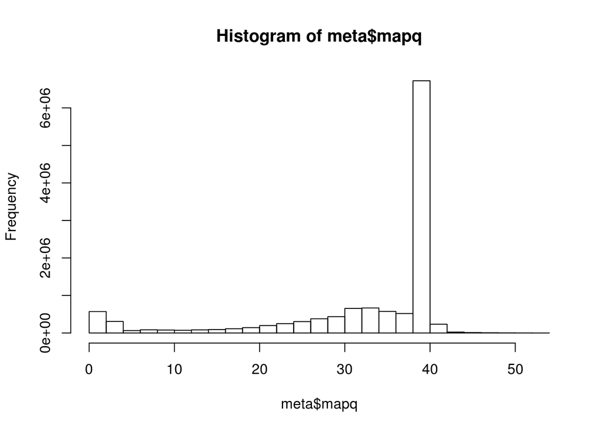

The exact definition of mapping quality will vary according to which aligner was used, or maybe even the version of the aligner. If we wish to impose such a threshold to do some filtering, we can do the following:-

```r
toremove <- which(meta$mapq < 5)
length(toremove)
```

```
## [1] 877025
```

```r
bam.filt <- bam[-toremove]
bam.filt
```

```
## GAlignments object with 11704655 alignments and 3 metadata columns:
##                    seqnames strand       cigar    qwidth     start
##                       <Rle>  <Rle> <character> <integer> <integer>
##   SRR081708.237649        1      +       1S67M        68     10003
##   SRR081679.742077        1      +         68M        68     10036
##   SRR079476.668457        1      +         68M        68     10036
##   SRR079511.938169        1      +         68M        68     10041
##   SRR081708.237649        1      -         68M        68     10041
##                ...      ...    ...         ...       ...       ...
##   SRR081721.198426   hs37d5      -         68M        68  35465836
##   SRR079422.510282   hs37d5      +         68M        68  35466096
##   SRR079422.510282   hs37d5      -    47M1D21M        68  35466133
##   SRR079560.307153   hs37d5      +         68M        68  35466270
##   SRR079560.307153   hs37d5      -         68M        68  35466357
##                          end     width     njunc |                     seq
##                    <integer> <integer> <integer> |          <DNAStringSet>
##   SRR081708.237649     10069        67         0 | GACCCTGACC...CTAACCCTAA
##   SRR081679.742077     10103        68         0 | CTAAGCCTAA...CCCGAACGCT
##   SRR079476.668457     10103        68         0 | CTAACCCTAA...CCCTAACCCT
##   SRR079511.938169     10108        68         0 | CCTAACCCTA...ACCCTAACCC
##   SRR081708.237649     10108        68         0 | CCTAACCCTA...ACCCTAACCC
##                ...       ...       ...       ... .                     ...
##   SRR081721.198426  35465903        68         0 | ATTCCATTCC...AGTGCAGATT
##   SRR079422.510282  35466163        68         0 | CACTTCATCA...CCATTCGATT
##   SRR079422.510282  35466201        69         0 | TTCGAATCTT...TACCATTCGA
##   SRR079560.307153  35466337        68         0 | ATTCGATTCC...CCATTTGATT
##   SRR079560.307153  35466424        68         0 | TCCGTTTGAT...ATTCCATTTG
##                         mapq      flag
##                    <integer> <integer>
##   SRR081708.237649         6       163
##   SRR081679.742077         5        99
##   SRR079476.668457        14        99
##   SRR079511.938169        15       163
##   SRR081708.237649        18        83
##                ...       ...       ...
##   SRR081721.198426        29       147
##   SRR079422.510282        24        99
##   SRR079422.510282        13       147
##   SRR079560.307153        32       163
##   SRR079560.307153        31        83
##   -------
##   seqinfo: 86 sequences from an unspecified genome
```

```r
length(bam.filt) / length(bam)
```

```
## [1] 0.9302935
```

Another field we might want to pay attention to is the `flag` of each read.

## Fun with flags!

### Exercise

- What categories of read to we have? HINT:-
- a vector of all flags can be obtained by `meta$flag`
- https://broadinstitute.github.io/picard/explain-flags.html

Depending on the kind of sequencing we have performed, we might be cautious about reads that are flagged as PCR or optical duplicates. Most downstream analysis tools will ignore these, but we rarely remove them altogether from the file.

The value of the flag is a combination of different quality indicators, so a PCR duplicate can be indicated by many different values. In our case, we don’t have many different flags, so it is not too much work to identify all duplicates.

```r
dups <- which(meta$flag %in% c(1107,1123,1171,1187))
length(dups)
```

```
## [1] 177715
```

```r
bam[dups]
```

```
## GAlignments object with 177715 alignments and 3 metadata columns:
##                    seqnames strand       cigar    qwidth     start
##                       <Rle>  <Rle> <character> <integer> <integer>
##   SRR081727.510557        1      +         68M        68     69672
##   SRR081682.538815        1      +         68M        68     69710
##   SRR081727.510557        1      -         68M        68     69835
##   SRR081682.538815        1      -         68M        68     69887
##    SRR084798.67606        1      +         68M        68    250104
##                ...      ...    ...         ...       ...       ...
##   SRR079397.640524   hs37d5      -         68M        68  35388153
##   SRR081743.817101   hs37d5      +         68M        68  35398415
##   SRR081743.817101   hs37d5      -         68M        68  35398421
##   SRR084838.868293   hs37d5      +         68M        68  35442905
##   SRR084838.868293   hs37d5      -         68M        68  35442963
##                          end     width     njunc |                     seq
##                    <integer> <integer> <integer> |          <DNAStringSet>
##   SRR081727.510557     69739        68         0 | TTACAGTGGT...ATCCTAATGA
##   SRR081682.538815     69777        68         0 | TAATCATCTC...GTCCAAAGCT
##   SRR081727.510557     69902        68         0 | TTTATTTATG...ATTCTGTGAT
##   SRR081682.538815     69954        68         0 | TATTTTATTC...AGACATGAAG
##    SRR084798.67606    250171        68         0 | GTATTTTTGG...CCTCAGGTGA
##                ...       ...       ...       ... .                     ...
##   SRR079397.640524  35388220        68         0 | GGTTTCAGAA...AGGCCGCCTG
##   SRR081743.817101  35398482        68         0 | CCATTCCATT...TTCCATTTCA
##   SRR081743.817101  35398488        68         0 | CATTCCATTC...TTCATTCCAT
##   SRR084838.868293  35442972        68         0 | CATTTGGGTT...TCCATTCCAT
##   SRR084838.868293  35443030        68         0 | TCCATTCCAT...ATTCCATTCT
##                         mapq      flag
##                    <integer> <integer>
##   SRR081727.510557         3      1123
##   SRR081682.538815         3      1123
##   SRR081727.510557         3      1171
##   SRR081682.538815         3      1171
##    SRR084798.67606         5      1123
##                ...       ...       ...
##   SRR079397.640524         6      1171
##   SRR081743.817101        25      1123
##   SRR081743.817101        27      1171
##   SRR084838.868293        34      1123
##   SRR084838.868293        35      1171
##   -------
##   seqinfo: 86 sequences from an unspecified genome
```

Another option is to produce a convenient matrix which tabulates what flags have been set for each read. From this table we can identify the duplicates

```r
flagMat <- bamFlagAsBitMatrix(meta$flag)
dim(flagMat)
```

```
## [1] 12581680       11
```

```r
head(flagMat)
```

```
##      isPaired isProperPair isUnmappedQuery hasUnmappedMate isMinusStrand
## [1,]        1            1               0               0             0
## [2,]        1            1               0               0             0
## [3,]        1            1               0               0             0
## [4,]        1            1               0               0             0
## [5,]        1            1               0               0             1
## [6,]        1            1               0               0             0
##      isMateMinusStrand isFirstMateRead isSecondMateRead
## [1,]                 1               0                1
## [2,]                 1               1                0
## [3,]                 1               1                0
## [4,]                 1               0                1
## [5,]                 0               1                0
## [6,]                 1               0                1
##      isSecondaryAlignment isNotPassingQualityControls isDuplicate
## [1,]                    0                           0           0
## [2,]                    0                           0           0
## [3,]                    0                           0           0
## [4,]                    0                           0           0
## [5,]                    0                           0           0
## [6,]                    0                           0           0
```

```r
table(flagMat[,11])
```

```
##
##        0        1
## 12403965   177715
```

If we wanted to ignore the duplicates from the start, we can infact tell `readGAlignments` to ignore them by making use of the `scanBamFlag` option

```r
bam.nodups <- readGAlignments(file="paired.bam", param=ScanBamParam(flag=scanBamFlag(isDuplicate = FALSE)))
```

Another situation where we might want to focus on a subset of reads from the start, is when we want to analyse a particular gene. Provided that the `.bam` file has been indexed (creating a `.bam.bai` file in the same directory), we can *very* quickly jump to a particular genomic region

```r
system.time(mygene.reads <- readGAlignments(file="paired.bam",param=ScanBamParam(which=mygene)))
```

```
##    user  system elapsed
##   0.112   0.002   6.100
```

```r
mygene.reads
```

```
## GAlignments object with 225 alignments and 0 metadata columns:
##         seqnames strand       cigar    qwidth     start       end
##            <Rle>  <Rle> <character> <integer> <integer> <integer>
##     [1]       17      +         76M        76   7577918   7577993
##     [2]       17      -         76M        76   7577930   7578005
##     [3]       17      +         76M        76   7578191   7578266
##     [4]       17      +         68M        68   7578195   7578262
##     [5]       17      +         68M        68   7578203   7578270
##     ...      ...    ...         ...       ...       ...       ...
##   [221]       17      +         68M        68   7596523   7596590
##   [222]       17      -         68M        68   7596639   7596706
##   [223]       17      +       67M1S        68   7597833   7597899
##   [224]       17      -         68M        68   7597888   7597955
##   [225]       17      +         68M        68   7598046   7598113
##             width     njunc
##         <integer> <integer>
##     [1]        76         0
##     [2]        76         0
##     [3]        76         0
##     [4]        68         0
##     [5]        68         0
##     ...       ...       ...
##   [221]        68         0
##   [222]        68         0
##   [223]        67         0
##   [224]        68         0
##   [225]        68         0
##   -------
##   seqinfo: 86 sequences from an unspecified genome
```

The region filer can be used in conjuction with the `what` argument to `ScanBamParam` function to provide a detailed picture of the reads for your gene

```r
mygene.reads <- readGAlignments(file="paired.bam",param=ScanBamParam(which=mygene, what=c("seq","mapq","flag","qual","isize")))
mygene.reads
```

```
## GAlignments object with 225 alignments and 5 metadata columns:
##         seqnames strand       cigar    qwidth     start       end
##            <Rle>  <Rle> <character> <integer> <integer> <integer>
##     [1]       17      +         76M        76   7577918   7577993
##     [2]       17      -         76M        76   7577930   7578005
##     [3]       17      +         76M        76   7578191   7578266
##     [4]       17      +         68M        68   7578195   7578262
##     [5]       17      +         68M        68   7578203   7578270
##     ...      ...    ...         ...       ...       ...       ...
##   [221]       17      +         68M        68   7596523   7596590
##   [222]       17      -         68M        68   7596639   7596706
##   [223]       17      +       67M1S        68   7597833   7597899
##   [224]       17      -         68M        68   7597888   7597955
##   [225]       17      +         68M        68   7598046   7598113
##             width     njunc |                     seq      mapq      flag
```

[output cut: 27 more lines]

## Pre-built databases of gene coordinates

Aside from the many useful software packages, Bioconductor also provides numerous annotation resources that we can utilise in our analysis. Firstly, we have a set of organism-level packages that can translate between different types of identifer. The package for humans is called `org.Hs.eg.db`. The advantage of such a package, rather than services such as biomaRt, is that we can do queries offline. The packages are updated every 6 months, so we can always be sure of what version of the relevant databases are being used.

```r
library(org.Hs.eg.db)
org.Hs.eg.db
```

```
## OrgDb object:
## | DBSCHEMAVERSION: 2.1
## | Db type: OrgDb
## | Supporting package: AnnotationDbi
## | DBSCHEMA: HUMAN_DB
## | ORGANISM: Homo sapiens
## | SPECIES: Human
## | EGSOURCEDATE: 2016-Mar14
## | EGSOURCENAME: Entrez Gene
## | EGSOURCEURL: ftp://ftp.ncbi.nlm.nih.gov/gene/DATA
## | CENTRALID: EG
## | TAXID: 9606
## | GOSOURCENAME: Gene Ontology
## | GOSOURCEURL: ftp://ftp.geneontology.org/pub/go/godatabase/archive/latest-lite/
## | GOSOURCEDATE: 20160305
## | GOEGSOURCEDATE: 2016-Mar14
## | GOEGSOURCENAME: Entrez Gene
## | GOEGSOURCEURL: ftp://ftp.ncbi.nlm.nih.gov/gene/DATA
## | KEGGSOURCENAME: KEGG GENOME
## | KEGGSOURCEURL: ftp://ftp.genome.jp/pub/kegg/genomes
## | KEGGSOURCEDATE: 2011-Mar15
## | GPSOURCENAME: UCSC Genome Bioinformatics (Homo sapiens)
## | GPSOURCEURL: ftp://hgdownload.cse.ucsc.edu/goldenPath/hg19
## | GPSOURCEDATE: 2010-Mar22
## | ENSOURCEDATE: 2016-Mar9
## | ENSOURCENAME: Ensembl
## | ENSOURCEURL: ftp://ftp.ensembl.org/pub/current_fasta
## | UPSOURCENAME: Uniprot
## | UPSOURCEURL: http://www.UniProt.org/
## | UPSOURCEDATE: Wed Mar 23 15:50:09 2016
```

```
##
## Please see: help('select') for usage information
```

There are several types of “key” we can use to make a query, and we have to specify one of these names.

```r
keytypes(org.Hs.eg.db)
```

```
##  [1] "ACCNUM"       "ALIAS"        "ENSEMBL"      "ENSEMBLPROT"
##  [5] "ENSEMBLTRANS" "ENTREZID"     "ENZYME"       "EVIDENCE"
##  [9] "EVIDENCEALL"  "GENENAME"     "GO"           "GOALL"
## [13] "IPI"          "MAP"          "OMIM"         "ONTOLOGY"
## [17] "ONTOLOGYALL"  "PATH"         "PFAM"         "PMID"
## [21] "PROSITE"      "REFSEQ"       "SYMBOL"       "UCSCKG"
## [25] "UNIGENE"      "UNIPROT"
```

For the given keytype we have chosen, we can also choose what data we want to retrieve. We can think of these as columns in a table, and the pre-defined values are given by:-

```r
columns(org.Hs.eg.db)
```

```
##  [1] "ACCNUM"       "ALIAS"        "ENSEMBL"      "ENSEMBLPROT"
##  [5] "ENSEMBLTRANS" "ENTREZID"     "ENZYME"       "EVIDENCE"
##  [9] "EVIDENCEALL"  "GENENAME"     "GO"           "GOALL"
## [13] "IPI"          "MAP"          "OMIM"         "ONTOLOGY"
## [17] "ONTOLOGYALL"  "PATH"         "PFAM"         "PMID"
## [21] "PROSITE"      "REFSEQ"       "SYMBOL"       "UCSCKG"
## [25] "UNIGENE"      "UNIPROT"
```

For example, if we want to know the *“Entrez”* ID for the gene BRCA1, we can do:-

```r
eg <- select(org.Hs.eg.db, keys="BRCA1", keytype = "SYMBOL",columns = "ENTREZID")
eg
```

```
##   SYMBOL ENTREZID
## 1  BRCA1      672
```

But we’re not restricted to just one type of information to return

```r
eg <- select(org.Hs.eg.db, keys=c("BRCA1","PTEN"), keytype = "SYMBOL",columns = c("ENTREZID","ENSEMBL"))
```

You should see that the above command prints a message to the screen:- `'select()' returned 1:many mapping between keys and columns`. This is not an error message and R has still been able to generate the output requested.

```r
eg
```

```
##   SYMBOL ENTREZID         ENSEMBL
## 1  BRCA1      672 ENSG00000012048
## 2   PTEN     5728 ENSG00000171862
## 3   PTEN     5728 ENSG00000283094
```

In this case, we have “many” (well, two) values of `ENSEMBL` for the gene `PTEN`. In practice this means we probably want to think carefully about merging this data with other tables.

### Exercise

You might expect to be able to retrieve information about the coordinates for a particular gene. This was supported until recently, but the recommended approach now is to use another class of packages which describe the structure of genes in more detail.

The packages with the prefix `TxDb....` represent the structure of all genes for a given organism in an efficient manner. For humans, we can use the package `TxDb.Hsapiens.UCSC.hg19.knownGene` to tell us about transcripts for the `hg19` build of the genome. The package was generated using tables from the [UCSC genome browser](https://www.genome.ucsc.edu/)

As with the `org.Hs.eg.db` package we can load the package and inspect the kind of mappings available to us.

```r
library(TxDb.Hsapiens.UCSC.hg19.knownGene)
txdb <- TxDb.Hsapiens.UCSC.hg19.knownGene
columns(txdb)
```

```
##  [1] "CDSCHROM"   "CDSEND"     "CDSID"      "CDSNAME"    "CDSSTART"
##  [6] "CDSSTRAND"  "EXONCHROM"  "EXONEND"    "EXONID"     "EXONNAME"
## [11] "EXONRANK"   "EXONSTART"  "EXONSTRAND" "GENEID"     "TXCHROM"
## [16] "TXEND"      "TXID"       "TXNAME"     "TXSTART"    "TXSTRAND"
## [21] "TXTYPE"
```

```r
keytypes(txdb)
```

```
## [1] "CDSID"    "CDSNAME"  "EXONID"   "EXONNAME" "GENEID"   "TXID"
## [7] "TXNAME"
```

You’ll see that all the mappings are regarding the coordinates and IDs of various genomic features. There is only one type of identifier used, in this case `Entrez ID`. If we know a genes Entrez ID, we can get the exon coordinates with the following query.

```r
mygene <- select(txdb, keys="672", columns = c("EXONCHROM","EXONSTART","EXONEND","EXONSTRAND"),keytype="GENEID")
mygene
```

```
##    GENEID EXONCHROM EXONSTRAND EXONSTART  EXONEND
## 1     672     chr17          -  41276034 41276132
## 2     672     chr17          -  41267743 41267796
## 3     672     chr17          -  41258473 41258550
## 4     672     chr17          -  41256885 41256973
## 5     672     chr17          -  41256139 41256278
## 6     672     chr17          -  41251792 41251897
## 7     672     chr17          -  41249261 41249306
## 8     672     chr17          -  41247863 41247939
## 9     672     chr17          -  41246761 41246877
## 10    672     chr17          -  41242961 41243049
## 11    672     chr17          -  41234421 41234592
## 12    672     chr17          -  41228505 41228628
## 13    672     chr17          -  41226348 41226538
## 14    672     chr17          -  41222945 41223255
```

[output cut: 20 more lines]

### Exercise

- Using the results from the previous exercise, retrieve the exon coordinates for the gene `PTEN`
- How about all transcripts for PTEN and BRCA1?

It is useful to be able to retrive the coordinates in this manner. However, we should now be familiar with the way intervals can be represented using `GRanges`. We have the ability to create a `GRanges` object from the result:-

```r
my.gr <- GRanges(mygene$EXONCHROM, IRanges(mygene$EXONSTART,mygene$EXONEND))
my.gr
```

```
## GRanges object with 34 ranges and 0 metadata columns:
##        seqnames               ranges strand
##           <Rle>            <IRanges>  <Rle>
##    [1]    chr17 [41276034, 41276132]      *
##    [2]    chr17 [41267743, 41267796]      *
##    [3]    chr17 [41258473, 41258550]      *
##    [4]    chr17 [41256885, 41256973]      *
##    [5]    chr17 [41256139, 41256278]      *
##    ...      ...                  ...    ...
##   [30]    chr17 [41231351, 41231416]      *
##   [31]    chr17 [41202079, 41202207]      *
##   [32]    chr17 [41322143, 41322420]      *
##   [33]    chr17 [41243117, 41246877]      *
##   [34]    chr17 [41262482, 41262597]      *
##   -------
##   seqinfo: 1 sequence from an unspecified genome; no seqlengths
```

A powerful feature of the transcript database packages is to allow the user to create a `GRanges` representation of *all* exons / transcripts for a particular organism. The function to do this is `exonsBy` (or equivalently `transcriptsBy`). The result is a *list* object that can be subset according to Entrez ID.

```r
allex <- exonsBy(txdb, "gene")
mygene <- allex[["672"]]
mygene
```

```
## GRanges object with 34 ranges and 2 metadata columns:
##        seqnames               ranges strand |   exon_id   exon_name
##           <Rle>            <IRanges>  <Rle> | <integer> <character>
##    [1]    chr17 [41196312, 41197819]      - |    227457        <NA>
##    [2]    chr17 [41199660, 41199720]      - |    227458        <NA>
##    [3]    chr17 [41201138, 41201211]      - |    227459        <NA>
##    [4]    chr17 [41202079, 41202207]      - |    227460        <NA>
##    [5]    chr17 [41203080, 41203134]      - |    227461        <NA>
##    ...      ...                  ...    ... .       ...         ...
##   [30]    chr17 [41276034, 41276132]      - |    227486        <NA>
##   [31]    chr17 [41277199, 41277340]      - |    227487        <NA>
##   [32]    chr17 [41277288, 41277500]      - |    227488        <NA>
##   [33]    chr17 [41277294, 41277468]      - |    227489        <NA>
##   [34]    chr17 [41322143, 41322420]      - |    227496        <NA>
##   -------
##   seqinfo: 93 sequences (1 circular) from hg19 genome
```

We are almost in a position to overlap our reads with the `GRanges` representation of our gene. First of all, we need the same trick from before to make sure the chromosome names are compatible

```r
seqlevelsStyle(mybam)
```

```
## [1] "NCBI"    "Ensembl"
```

```r
seqlevelsStyle(mygene)
```

```
## [1] "UCSC"
```

```r
seqlevelsStyle(mygene) <- "Ensembl"
mygene
```

```
## GRanges object with 34 ranges and 2 metadata columns:
##        seqnames               ranges strand |   exon_id   exon_name
##           <Rle>            <IRanges>  <Rle> | <integer> <character>
##    [1]       17 [41196312, 41197819]      - |    227457        <NA>
##    [2]       17 [41199660, 41199720]      - |    227458        <NA>
##    [3]       17 [41201138, 41201211]      - |    227459        <NA>
##    [4]       17 [41202079, 41202207]      - |    227460        <NA>
##    [5]       17 [41203080, 41203134]      - |    227461        <NA>
##    ...      ...                  ...    ... .       ...         ...
##   [30]       17 [41276034, 41276132]      - |    227486        <NA>
##   [31]       17 [41277199, 41277340]      - |    227487        <NA>
##   [32]       17 [41277288, 41277500]      - |    227488        <NA>
##   [33]       17 [41277294, 41277468]      - |    227489        <NA>
##   [34]       17 [41322143, 41322420]      - |    227496        <NA>
##   -------
##   seqinfo: 93 sequences (1 circular) from hg19 genome
```

Furthermore, since we know we are only interested in the reads from chromosome 17, we could subset the reads accordingly.

```r
mybam.chr17 <- keepSeqlevels(mybam, "17")
```

```r
mybam.chr17[mybam.chr17 %over% mygene]
```

```
## GAlignments object with 345 alignments and 0 metadata columns:
##         seqnames strand       cigar    qwidth     start       end
##            <Rle>  <Rle> <character> <integer> <integer> <integer>
##     [1]       17      -         76M        76  41197373  41197448
##     [2]       17      -         68M        68  41197677  41197744
##     [3]       17      -         68M        68  41197707  41197774
##     [4]       17      -         76M        76  41197734  41197809
##     [5]       17      -         68M        68  41197780  41197847
##     ...      ...    ...         ...       ...       ...       ...
##   [341]       17      -         68M        68  41276093  41276160
##   [342]       17      -         76M        76  41276099  41276174
##   [343]       17      -         68M        68  41277212  41277279
##   [344]       17      -         68M        68  41277341  41277408
##   [345]       17      -         68M        68  41322151  41322218
##             width     njunc
##         <integer> <integer>
##     [1]        76         0
##     [2]        68         0
##     [3]        68         0
##     [4]        76         0
##     [5]        68         0
##     ...       ...       ...
##   [341]        68         0
##   [342]        76         0
##   [343]        68         0
##   [344]        68         0
##   [345]        68         0
##   -------
##   seqinfo: 1 sequence from an unspecified genome
```

NOTE:- it also seems that the Mitochondial sequence is a different length in the reference that these reads were aligned to, compared to the transcript database. It may seem like a trivial difference, but will cause an error if we don’t perform the subset.

```
Error in mergeNamedAtomicVectors(seqlengths(x), seqlengths(y), what = c("sequence",  :
  sequence MT has incompatible seqlengths:
  - in 'x': 16569
  - in 'y': 16571
```

```r
countOverlaps(mygene,mybam.chr17)
```

```
##  [1]   8   6   4   0   1  12   3   3   5  24   5   8   8   1  13   2 207
## [18] 204   4   1   2   7   7  18   7   2   2   0   0   4   1   1   1   1
```